# ACIC Data Challenge 2022 Illustration

Yuqin Wei

The goal of this document is to illustrate:  
1. How to get ATT for this challenge using one replicate of data. The method of choice is propensity score weighting (IPTW-ATT) + Non-linear DID.  
2. How to (partially) create our own data generation process and how to calibrate a true ATT effect for that DGP.  
3. How to evaluate performance for causal inference methods.

### Data Preparation

The whole analysis only look at replicate 0001. All four csv files were loaded and merged appropriately. We will need a patient level file to fit propensity score model, and a patient-year level file to fit the outcome regression. Y includes some negative outliers and truncated to 0.01.

```r
# load rep_0001 processed on snowflake, or local machine, this is a patient-year level data
if (Sys.info()["sysname"] == "Darwin") {
  rep_no <- "0001"
  folder <- "../Data/track1a"
  patient <- read.csv(file.path(folder, "patient", paste0("acic_patient_", rep_no, ".csv")))
  patient_year <- read.csv(file.path(folder, "patient_year", paste0("acic_patient_year_", rep_no, ".csv")))
  practice <- read.csv(file.path(folder, "practice", paste0("acic_practice_", rep_no, ".csv")))
  practice_year <- read.csv(file.path(folder, "practice_year", paste0("acic_practice_year_", rep_no, ".csv")))

  rep_0001 <- patient_year %>%
    left_join(patient) %>%
    left_join(practice) %>%
    left_join(practice_year %>% select(id.practice, year, Z, post))

  colnames(rep_0001) <- toupper(colnames(rep_0001))
  colnames(rep_0001) <- gsub('\\.', '_', colnames(rep_0001))

} else {
  rep_0001 <- spark_read_source(
    sc=sc,
    name = "rep_0001",
    source = "snowflake",
    options = list(
      sfUrl = sfUrl,
      sfUser = user,
      sfPassword = password,
      sfDatabase = sfDatabase,
      sfSchema = sfSchema,
      sfWarehouse = sfWarehouse,
      sfRole = sfRole,
      dbtable = "rep_0001"
    )
  )
}
head(rep_0001)
```

```
##   ID_PATIENT YEAR          Y ID_PRACTICE        V1 V2 V3         V4 V5 X1 X2 X3
## 1          1    1  3632.1660           1 14.526039  3  0  1.8412825  B  0  A  1
## 2          2    1   402.2605           1  7.451295  4  0  0.0498057  A  0  A  1
## 3          3    1   618.1789           1 17.300977  1  1  1.5725610  A  0  A  1
## 4          4    1  1767.4254           1 13.706609  3  1 -0.3980635  A  0  A  1
## 5          5    1   709.3144           1  8.814000  1  1  0.1393795  A  0  A  1
## 6          6    1 12331.7486           1 10.181214  4  1  0.8559703  A  0  A  1
##   X4 X5       X6       X7        X8       X9 Z POST
## 1  A  1 20.77408 14.15325 0.1611263 43.43187 1    0
## 2  A  1 20.77408 14.15325 0.1611263 43.43187 1    0
## 3  A  1 20.77408 14.15325 0.1611263 43.43187 1    0
## 4  A  1 20.77408 14.15325 0.1611263 43.43187 1    0
## 5  A  1 20.77408 14.15325 0.1611263 43.43187 1    0
## 6  A  1 20.77408 14.15325 0.1611263 43.43187 1    0
```

```r
# clean some Y outliers
# create a patient level df, confirm that V and X are time-invariant features
patient_year_df <- as.data.frame(rep_0001) %>% mutate(Y = pmax(Y, 0.01))
patient_df <-
  patient_year_df %>%
  select(ID_PATIENT, ID_PRACTICE, Z, V1, V2, V3, V4, V5, X1, X2, X3, X4, X5, X6, X7, X8, X9) %>%
  distinct
nrow(patient_df) %>% print
```

```
## [1] 426449
```

```r
nrow(patient_year_df) %>% print
```

```
## [1] 1318081
```

```r
length(unique(patient_year_df$ID_PATIENT)) %>% print
```

```
## [1] 426449
```

### Propensity Score Weighting (IPTW-ATT)

I use `WeightIt` package to simplify the process of weight calculation, but essentially it fits a logistic regression

```
Z ~ V1
+ V2 + V3 + V4 + V5 + X1 + X2 + X3 + X4 + X5 + X6 + X7 + X8 + X9
```

using the patient level data (without any other ML tricks such as CV, etc.), and calculated the fitted probability for each patient. Then inverse probability treatment weight can be calculated. Here we use ATT weight, it is slightly different from ATE weight. ATT weight looks like: for treatment group, everyone has a weight of constant 1. For the control group, $weight = c*p/(1-p)$ where c standardize the sum of control group weight to be similar to the original population (standardized weight).

Before running the weightit package, we can quickly run a logit model and take a look at the coefficients. We will see that V1, V2 and V3 hardly predict Z so we can consider drop, or use a model with regularization to automatically drop those terms.

```r
#ps_model <- lme4::glmer(Z ~ V1 + V2 + V3 + V4 + V5 + X1 + X2 + X3 + X4 + X5 + X6 + X7 + X8 + X9 + (1 | ID_PRACTICE),
#              data = rep_0001_patient_df, family = binomial)
ps_model <- glm(Z ~ V1 + V2 + V3 + V4 + V5 + X1 + X2 + X3 + X4 + X5 + X6 + X7 + X8 + X9,
              data = patient_df, family = binomial)
summary(ps_model)
```

```
##
## Call:
## glm(formula = Z ~ V1 + V2 + V3 + V4 + V5 + X1 + X2 + X3 + X4 +
##     X5 + X6 + X7 + X8 + X9, family = binomial, data = patient_df)
##
## Deviance Residuals:
##     Min       1Q   Median       3Q      Max
## -2.1652  -0.9261  -0.4553   1.0203   2.4753
##
## Coefficients:
##               Estimate Std. Error  z value Pr(>|z|)
## (Intercept)  5.567e-01  2.298e-02   24.226   <2e-16 ***
## V1          -3.608e-04  7.809e-04   -0.462   0.6441
## V2          -1.102e-03  2.015e-03   -0.547   0.5844
## V3           8.073e-03  7.368e-03    1.096   0.2732
## V4           7.848e-02  3.819e-03   20.548   <2e-16 ***
## V5B         -1.693e-01  8.819e-03  -19.194   <2e-16 ***
## V5C         -2.050e-01  1.198e-02  -17.118   <2e-16 ***
## X1           2.844e-01  7.640e-03   37.228   <2e-16 ***
## X2B          2.183e-02  8.580e-03    2.545   0.0109 *
## X2C          3.358e-01  9.641e-03   34.827   <2e-16 ***
## X3           1.373e-01  7.338e-03   18.710   <2e-16 ***
## X4B          2.699e-01  9.506e-03   28.391   <2e-16 ***
## X4C          7.044e-01  1.250e-02   56.363   <2e-16 ***
## X5          -3.306e-01  1.074e-02  -30.789   <2e-16 ***
## X6          -8.165e-02  4.863e-04 -167.913   <2e-16 ***
## X7           2.948e-02  9.659e-04   30.523   <2e-16 ***
## X8           1.322e+00  2.624e-02   50.391   <2e-16 ***
## X9           1.834e-02  8.976e-05  204.288   <2e-16 ***
## ---
## Signif. codes:  0 '***' 0.001 '**' 0.01 '*' 0.05 '.' 0.1 ' ' 1
##
## (Dispersion parameter for binomial family taken to be 1)
##
##     Null deviance: 585192  on 426448  degrees of freedom
## Residual deviance: 485677  on 426431  degrees of freedom
## AIC: 485713
##
## Number of Fisher Scoring iterations: 4
```

We use `weightit` function to fit the same model and also generate ATT weights. A few diagnostics on the weights were performed: 1. check propensity score distribution before and after weighting. Recall $pscore = P(Z|X)$, it is a probability between 0 and 1.  
2. check weight distribution. Since we use ATT weight, we only check the distribution for the control. (All treated sample will be assign a weight of 1)  
3. check covariate balance before and after weighting.

From the density plot we can see that the two curves are getting closer after weighting, while there may still be room for improvement. The distribution looks like a multi-modal distribution. This gives us the hint that the propensity score is heavily a function of practice, and that’s why we see those clustering effects. This may help us improve the model selection for ps estimation. And the treated group curve didn’t move at all, this makes sense since we are using ATT weight and weight == 1 for the treated group.

Not much to say about the weight distribution plot. We expect the distribution centered at 1 after standardization and it should be more or less symmetric on log scale. If extreme weights are observed, this indicates samples with poor overlaps and sometimes weight truncation is used for more robust results. (Imagine a weight = 10 is similar to ten treatment match to one control, that control sample seems over represented.)

From the covariate balance table and chart we see that covariates are much more balanced after weighting (by checking balance score, Standardized Mean Difference). Typically the rule-of-thumb is to use 0.1 as the threshold and claim a balance if SMD < 0.1. In this case, X8 is the only variable marginally failed the check. We can try some other methods to achieve a better balance on X8 but let’s move on for now.

```r
weightit_model <- weightit(Z ~ V1 + V2 + V3 + V4 + V5 + X1 + X2 + X3 + X4 + X5 + X6 + X7 + X8 + X9,
              data = patient_df, method = "ps", estimand = "ATT")
```

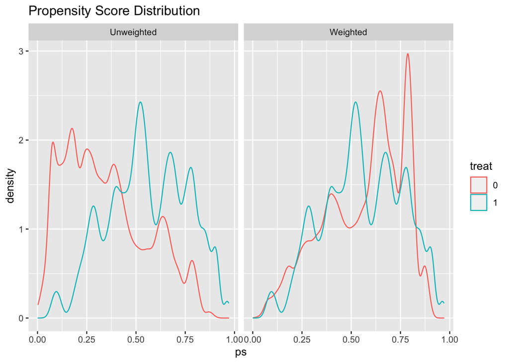

```r
plot_weightit <- function(model) {
  require(ggplot2)
  options(repr.plot.width=1000, repr.plot.height=300)
  plot_df <-
    rbind(
      data.frame(phase = "Unweighted", weights = 1, treat = model$treat, ps = model$ps),
      data.frame(phase = "Weighted", weights = model$weights, treat = model$treat, ps = model$ps)
    )
  plot_df$phase <- as.factor(plot_df$phase)
  plot_df$treat <- as.factor(plot_df$treat)
  ggplot(plot_df) + geom_density(aes(x = ps, color = treat, weight = weights)) + facet_grid(~ phase) + ggtitle("Propensity Score Distribution")
}
plot_weightit(weightit_model)
```

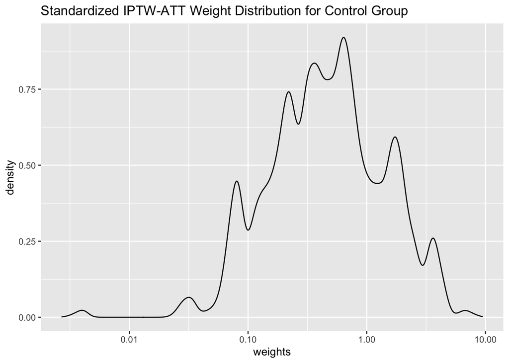

```r
plot_weightit_weight <- function(model) {
  require(ggplot2)
  options(repr.plot.width=1000, repr.plot.height=300)
  plot_df <-
    data.frame(weights = model$weights, treat = model$treat) %>%
    filter(treat == 0)
  ggplot(plot_df) + geom_density(aes(x = weights)) + ggtitle("Standardized IPTW-ATT Weight Distribution for Control Group") + scale_x_log10()
}
plot_weightit_weight(weightit_model)
```

```r
# Check covariate balance
# cov_lst <- c("V1", "V2", "V3", "V4", "V5", "X1", "X2", "X3", "X4", "X5", "X6", "X7", "X8", "X9")
bal_tab <- bal.tab(weightit_model, un = T, disp = c("means"))
bal_tab
```

```
## Call
##  weightit(formula = Z ~ V1 + V2 + V3 + V4 + V5 + X1 + X2 + X3 +
##     X4 + X5 + X6 + X7 + X8 + X9, data = patient_df, method = "ps",
##     estimand = "ATT")
##
## Balance Measures
##                Type  M.0.Un  M.1.Un Diff.Un M.0.Adj M.1.Adj Diff.Adj
## prop.score Distance  0.3481  0.5584  1.0593  0.5645  0.5584  -0.0310
## V1          Contin. 11.6241 11.5147 -0.0235 11.5151 11.5147  -0.0001
## V2          Contin.  2.9958  2.9906 -0.0030  2.9933  2.9906  -0.0015
## V3           Binary  0.5168  0.5289  0.0122  0.5281  0.5289   0.0009
## V4          Contin. -0.0728 -0.0037  0.0689 -0.0064 -0.0037   0.0027
## V5_A         Binary  0.6782  0.7173  0.0391  0.7074  0.7173   0.0099
## V5_B         Binary  0.2160  0.1927 -0.0233  0.2008  0.1927  -0.0082
## V5_C         Binary  0.1058  0.0901 -0.0158  0.0918  0.0901  -0.0017
## X1           Binary  0.5403  0.5880  0.0477  0.5971  0.5880  -0.0091
## X2_A         Binary  0.3804  0.3597 -0.0207  0.4153  0.3597  -0.0556
## X2_B         Binary  0.3661  0.3448 -0.0214  0.2856  0.3448   0.0592
## X2_C         Binary  0.2535  0.2955  0.0420  0.2991  0.2955  -0.0036
## X3           Binary  0.5194  0.5405  0.0212  0.4759  0.5405   0.0647
## X4_A         Binary  0.7805  0.6930 -0.0875  0.7047  0.6930  -0.0117
## X4_B         Binary  0.1533  0.1849  0.0316  0.1510  0.1849   0.0339
## X4_C         Binary  0.0663  0.1221  0.0558  0.1443  0.1221  -0.0222
## X5           Binary  0.5059  0.4685 -0.0373  0.4926  0.4685  -0.0241
## X6          Contin. 30.7502 26.1843 -0.7076 25.8740 26.1843   0.0481
## X7          Contin.  8.7544  9.1895  0.0683  9.3906  9.1895  -0.0316
## X8          Contin.  0.3971  0.4261  0.2162  0.4120  0.4261   0.1052
## X9          Contin. 11.3486 41.2998  0.7595 40.9652 41.2998   0.0085
##
## Effective sample sizes
##             Control Treated
## Unadjusted 238470.   187979
## Adjusted   100265.1  187979
```

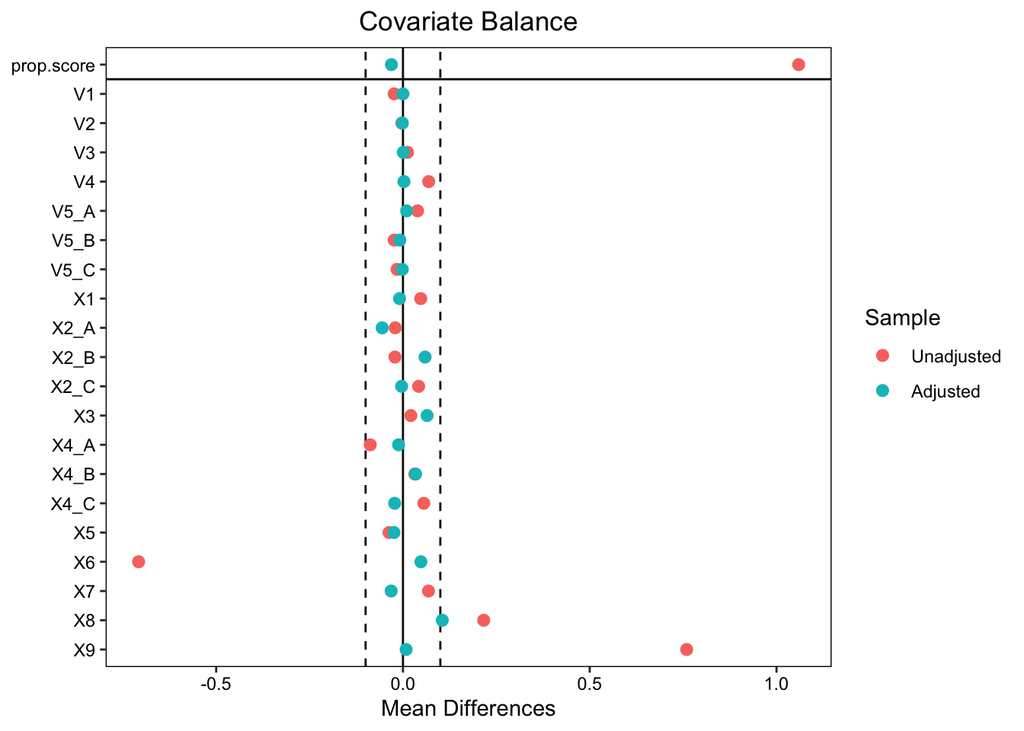

```r
love.plot(bal_tab, threshold = .1)
```

```r
## Merge weights on the longitudinal data
patient_df$weights <- weightit_model$weights
patient_year_df <- patient_year_df %>%
  left_join(patient_df %>% select(ID_PATIENT, weights))
```

### Outcome Model and ATT Estimation

Using weighted samples, we can model the longitudinal outcomes Y using a DID model. The simplest form of DID model calculate the ‘change’ in the intervention arm and the ‘change’ in the control arm, claim that the difference in the change is the causal effect from the intervention. This can usually be achieved by fitting a linear regression (OLS) with post:intervention interaction, and the interaction term is the DID estimates. The problem here is more complicated in a few ways: 1. We have four years of data, so the annual trend should be adjusted and the estimand are year 3 and year 4 ATT respectively, so we need two interaction terms.  
2. Cost data are highly skewed and usually should be modeled following a non-linear transformation. Puhani 2012 (https://ftp.iza.org/dp3478.pdf) described a method to construct ATT for non-linear DID model.

Finally, we can also run a model by adding (X, V). This is considered as a doubly-robust approach.

We can try the naive DID model with OLS, and explore some other options. The good news is, as long as we using the weights we created before, we no longer need to worry about X and V any more.

To note that, since weighted regression suffer from heteroskedasticity issue (unequal variance, violates iid assumption!), robust sandwich estimator is used to quantify CI (wider than without s.e. adjustment, while keep point estimates the same.)

```r
# manually assign two interaction terms, will be useful later
patient_year_df <- patient_year_df %>%
  mutate(Z_YEAR3 = as.numeric(Z == 1 & YEAR == 3),
         Z_YEAR4 = as.numeric(Z == 1 & YEAR == 4))

## Naive DID model, estimate year 3 and 4 separately
cost_model1 <- lm(Y ~ Z + factor(YEAR) + Z_YEAR3 + Z_YEAR4, data = patient_year_df, weights = weights)
summary(cost_model1)
```

```
##
## Call:
## lm(formula = Y ~ Z + factor(YEAR) + Z_YEAR3 + Z_YEAR4, data = patient_year_df,
##     weights = weights)
##
## Weighted Residuals:
##    Min     1Q Median     3Q    Max
##  -3347   -749   -435    -55 190306
##
## Coefficients:
##               Estimate Std. Error t value Pr(>|t|)
## (Intercept)    880.079      5.379 163.609  < 2e-16 ***
## Z               12.135      6.217   1.952  0.05093 .
## factor(YEAR)2  170.913      6.217  27.493  < 2e-16 ***
## factor(YEAR)3  286.577      8.217  34.875  < 2e-16 ***
## factor(YEAR)4  420.665      8.218  51.187  < 2e-16 ***
## Z_YEAR3         35.208     10.782   3.265  0.00109 **
## Z_YEAR4         26.880     10.790   2.491  0.01273 *
## ---
## Signif. codes:  0 '***' 0.001 '**' 0.01 '*' 0.05 '.' 0.1 ' ' 1
##
## Residual standard error: 2384 on 1318074 degrees of freedom
## Multiple R-squared:  0.004076,   Adjusted R-squared:  0.004071
## F-statistic: 899.1 on 6 and 1318074 DF,  p-value: < 2.2e-16
```

The causal effects are two interaction terms here, so 35 and 27 for YEAR3 and YEAR4.

```r
## robust SE is needed for weighted model
confint.robust <- function (object, parm, level = 0.95, ...)
{
    cf <- coef(object)
    pnames <- names(cf)
    if (missing(parm))
        parm <- pnames
    else if (is.numeric(parm))
        parm <- pnames[parm]
    a <- (1 - level)/2
    a <- c(a, 1 - a)
    pct <- stats:::format.perc(a, 3)
    fac <- qnorm(a)
    ci <- array(NA, dim = c(length(parm), 2L), dimnames = list(parm,
        pct))
    ses <- sqrt(diag(sandwich::vcovHC(object, type="HC1")))[parm]
    ci[] <- cf[parm] + ses %o% fac
    ci
}
# confint.default(cost_model1, level = 0.9)
confint.robust(cost_model1, level = 0.9)
```

```
##                      5 %      95 %
## (Intercept)   865.448206 894.70936
## Z              -1.285470  25.55551
## factor(YEAR)2 157.481998 184.34416
## factor(YEAR)3 265.945194 307.20917
## factor(YEAR)4 398.224168 443.10521
## Z_YEAR3        12.479700  57.93658
## Z_YEAR4         2.302819  51.45621
```

```r
## Naive DID model, estimate year 3 and 4 together
## The interaction term will serve like a weighted average across two years
cost_model2 <- lm(Y ~ Z + factor(YEAR) + Z:POST, data = patient_year_df, weights = weights)
summary(cost_model2)
```

```
##
## Call:
## lm(formula = Y ~ Z + factor(YEAR) + Z:POST, data = patient_year_df,
##     weights = weights)
##
## Weighted Residuals:
##    Min     1Q Median     3Q    Max
##  -3341   -749   -435    -55 190312
##
## Coefficients:
##               Estimate Std. Error t value Pr(>|t|)
## (Intercept)    880.079      5.379 163.609  < 2e-16 ***
## Z               12.135      6.217   1.952  0.05093 .
## factor(YEAR)2  170.913      6.217  27.493  < 2e-16 ***
## factor(YEAR)3  288.645      7.612  37.920  < 2e-16 ***
## factor(YEAR)4  418.596      7.612  54.989  < 2e-16 ***
## Z:POST          31.048      8.803   3.527  0.00042 ***
## ---
## Signif. codes:  0 '***' 0.001 '**' 0.01 '*' 0.05 '.' 0.1 ' ' 1
##
## Residual standard error: 2384 on 1318075 degrees of freedom
## Multiple R-squared:  0.004076,   Adjusted R-squared:  0.004072
## F-statistic:  1079 on 5 and 1318075 DF,  p-value: < 2.2e-16
```

```r
# Non-linear DID model, Punahi method
# We assume a gamma model with identity link. Need to visit the assumption later.
cost_model3 <- glm(Y ~ Z + factor(YEAR) + Z_YEAR3 + Z_YEAR4 , data = patient_year_df, weights = weights, family = Gamma("identity"))
#cost_model3 <- glm(Y ~ Z + factor(YEAR) + Z_YEAR3 + Z_YEAR4 , data = patient_year_df, weights = weights, family = inverse.gaussian)
summary(cost_model3)
```

```
##
## Call:
## glm(formula = Y ~ Z + factor(YEAR) + Z_YEAR3 + Z_YEAR4, family = Gamma("identity"),
##     data = patient_year_df, weights = weights)
##
## Deviance Residuals:
##    Min      1Q  Median      3Q     Max
## -6.254  -1.046  -0.554  -0.053  33.573
##
## Coefficients:
##               Estimate Std. Error t value Pr(>|t|)
## (Intercept)    884.440      4.537 194.928  < 2e-16 ***
## Z                3.573      5.533   0.646  0.51848
## factor(YEAR)2  170.713      5.620  30.374  < 2e-16 ***
## factor(YEAR)3  282.216      8.106  34.816  < 2e-16 ***
## factor(YEAR)4  416.303      8.757  47.537  < 2e-16 ***
## Z_YEAR3         43.771     11.186   3.913 9.12e-05 ***
## Z_YEAR4         35.442     12.130   2.922  0.00348 **
## ---
## Signif. codes:  0 '***' 0.001 '**' 0.01 '*' 0.05 '.' 0.1 ' ' 1
##
## (Dispersion parameter for Gamma family taken to be 4.883885)
##
##     Null deviance: 1734822  on 1318080  degrees of freedom
## Residual deviance: 1709294  on 1318074  degrees of freedom
## AIC: 18776897
##
## Number of Fisher Scoring iterations: 4
```

```r
confint.robust(cost_model3, level = 0.9)
```

```
##                     5 %      95 %
## (Intercept)   869.29023 899.59034
## Z             -10.55745  17.70246
## factor(YEAR)2 157.25946 184.16582
## factor(YEAR)3 261.21212 303.21924
## factor(YEAR)4 393.52057 439.08579
## Z_YEAR3        20.61622  66.92509
## Z_YEAR4        10.47085  60.41322
```

```r
# ATT can be calculated by switching on/off interaction terms. We will see the result match with coefficients! This is only true for some family and some link function.

patient_year_df_3 <- patient_year_df %>% filter(YEAR == 3, Z == 1)
pred_3_1 <- patient_year_df_3 %>% predict(cost_model3, newdata = ., type = "response")
pred_3_0 <- patient_year_df_3 %>% mutate(Z_YEAR3 = 0) %>% predict(cost_model3, newdata = ., type = "response")
ATT3 <- mean(pred_3_1 - pred_3_0)

pred_4_1 <- patient_year_df %>% filter(YEAR == 4, Z == 1) %>% predict(cost_model3, newdata = ., type = "response")
pred_4_0 <- patient_year_df %>% filter(YEAR == 4, Z == 1) %>% mutate(Z_YEAR4 = 0) %>% predict(cost_model3, newdata = ., type = "response")
ATT4 <- mean(pred_4_1 - pred_4_0)

print(c(ATT3, ATT4))
```

```
## [1] 43.77066 35.44203
```

```r
# Actually the Punahi method in DID model was designed without propensity score at all. So we can run a regression model by adjusting all X and check the result.
# There is some convergence issue so I dropped V4
# partial solved the issue but not converge well, leave it as it is for now.
cost_model4 <- glm(Y ~ Z + factor(YEAR) + Z_YEAR3 + Z_YEAR4 + (V1 + V2 + V3
                   # + V4
                   + V5 + X1 + X2 + X3 + X4 + X5 + X6 + X7 + X8 + X9)
                   , data = patient_year_df, weights = weights, family = Gamma("identity"))
summary(cost_model4)
```

```
##
## Call:
## glm(formula = Y ~ Z + factor(YEAR) + Z_YEAR3 + Z_YEAR4 + (V1 +
##     V2 + V3 + V5 + X1 + X2 + X3 + X4 + X5 + X6 + X7 + X8 + X9),
##     family = Gamma("identity"), data = patient_year_df, weights = weights)
##
## Deviance Residuals:
##     Min       1Q   Median       3Q      Max
## -6.1471  -1.0343  -0.5436  -0.0454  28.9111
##
## Coefficients:
##                 Estimate Std. Error t value Pr(>|t|)
## (Intercept)   1008.69191   14.28385  70.618  < 2e-16 ***
## Z                1.54727    5.29082   0.292 0.769948
## factor(YEAR)2  133.91571    5.33328  25.109  < 2e-16 ***
## factor(YEAR)3  223.99261    7.62865  29.362  < 2e-16 ***
## factor(YEAR)4  347.31412    8.24128  42.143  < 2e-16 ***
## Z_YEAR3         49.64366   10.50042   4.728 2.27e-06 ***
## Z_YEAR4         46.48351   11.40031   4.077 4.55e-05 ***
## V1             -11.43342    0.37319 -30.637  < 2e-16 ***
## V2              -1.94536    1.19394  -1.629 0.103237
## V3             329.40703    4.34046  75.892  < 2e-16 ***
## V5B            -46.52905    5.26496  -8.837  < 2e-16 ***
## V5C            -62.69126    7.06237  -8.877  < 2e-16 ***
## X1              17.71640    4.70241   3.768 0.000165 ***
## X2B            -45.55646    5.37069  -8.482  < 2e-16 ***
## X2C            -14.20375    5.80432  -2.447 0.014401 *
## X3             -20.58312    4.41903  -4.658 3.20e-06 ***
## X4B            -85.83905    5.54637 -15.477  < 2e-16 ***
## X4C            -65.17940    6.48933 -10.044  < 2e-16 ***
## X5             -34.47893    6.68090  -5.161 2.46e-07 ***
## X6              -0.99188    0.31284  -3.171 0.001521 **
## X7               0.05419    0.58467   0.093 0.926152
## X8             -88.96164   16.20637  -5.489 4.04e-08 ***
## X9               0.13264    0.05321   2.493 0.012683 *
## ---
## Signif. codes:  0 '***' 0.001 '**' 0.01 '*' 0.05 '.' 0.1 ' ' 1
##
## (Dispersion parameter for Gamma family taken to be 4.810827)
##
##     Null deviance: 1734822  on 1318080  degrees of freedom
## Residual deviance: 1667536  on 1318058  degrees of freedom
## AIC: 18741803
##
## Number of Fisher Scoring iterations: 25
```

```r
# ATT can be calculated by switching on/off interaction terms. Specifically:
patient_year_df_3 <- patient_year_df %>% filter(YEAR == 3, Z == 1)
pred_3_1 <- patient_year_df_3 %>% predict(cost_model4, newdata = ., type = "response")
pred_3_0 <- patient_year_df_3 %>% mutate(Z_YEAR3 = 0) %>% predict(cost_model4, newdata = ., type = "response")
ATT3 <- mean(pred_3_1 - pred_3_0)

pred_4_1 <- patient_year_df %>% filter(YEAR == 4, Z == 1) %>% predict(cost_model4, newdata = ., type = "response")
pred_4_0 <- patient_year_df %>% filter(YEAR == 4, Z == 1) %>% mutate(Z_YEAR4 = 0) %>% predict(cost_model4, newdata = ., type = "response")
ATT4 <- mean(pred_4_1 - pred_4_0)

print(c(ATT3, ATT4))
```

```
## [1] 49.64366 46.48351
```

We don’t know the performance of all results above. You can try your own methods see if they are similar to the numbers I got or not. To understand model performance, we will have to use our own DGP to generate data, quantify true effect, run whatever your favorate methods many times on many different realizations and summarize performance. (This is pretty much ACIC challenge organizer’s job.)